# Лабораторная работа №11

Операционные системы

Гасанова Ш. Ч.

Российский университет дружбы народов, Москва, Россия

24 апреля 2025

## Цель

Получить практические навыки работы с редактором Emacs.

## Задание

1. Открыть emacs и создать файл lab11.sh с помощью комбинации Ctrl-x Ctrl-f
2. Набрать данный текст
3. Сохранить файл с помощью комбинации Ctrl-x Ctrl-s (C-x C-s).
4. Проделать с текстом стандартные процедуры редактирования
5. Научиться использовать команды по перемещению курсора
6. Осуществить команды по управлению буферами
7. Осуществить команды по управлению окнами
8. Освоить режим поиска

## Выполнение лабораторной работы

Открываю emacs и создаю файл lab11.sh с помощью комбинации Ctrl-x Ctrl-f

[figure not shown]

Открытие emacs

## Выполнение лабораторной работы

[figure not shown]

Создание файла

## Выполнение лабораторной работы

Ввожу текст

[figure not shown]

Ввод текста

## Выполнение лабораторной работы

Сохраняю файл с помощью комбинации Ctrl-x Ctrl-s

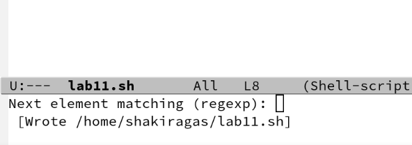

Сохранение

## Выполнение лабораторной работы

Вырезаю с помощью C-k целую строку и вставляю эту строку в конец файла (C-y)

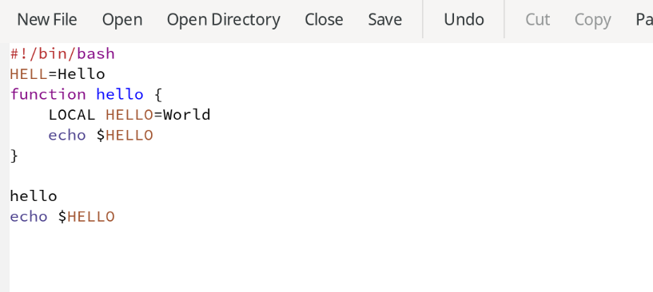

Вырезание и вставка строки

## Выполнение лабораторной работы

Выделяю область текста (C-space) и копирую в буфер обмена (M-w)

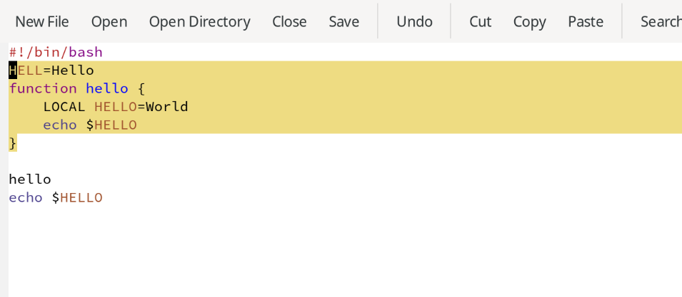

Копирование текста

## Выполнение лабораторной работы

Вставляю текст в конец файла

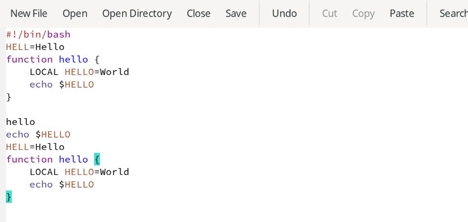

Вставка

## Выполнение лабораторной работы

Снова выделяю эту область и на этот раз вырезаю её (C-w)

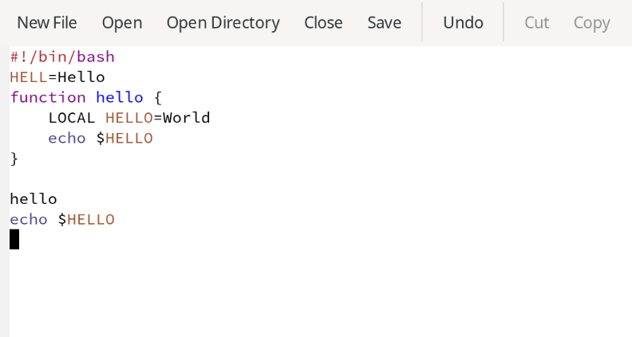

Вырезание

## Выполнение лабораторной работы

Отменяю последнее действие (C-/)

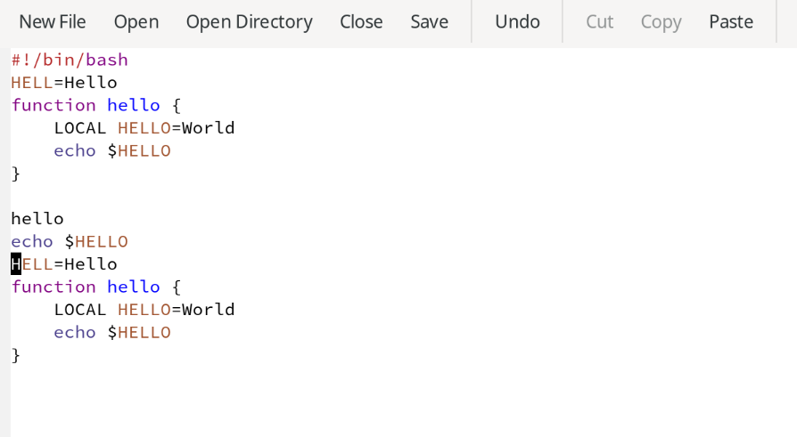

Отмена действия

## Выполнение лабораторной работы

Перемещаю курсор в начало строки (C-a)

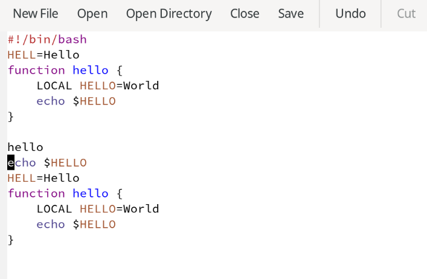

Курсор в начале строки

## Выполнение лабораторной работы

Перемещаю курсор в конец строки (C-e)

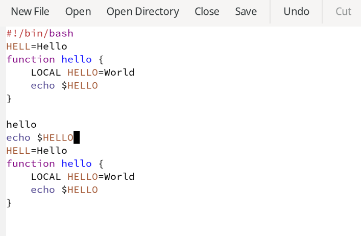

Курсор в конце строки

## Выполнение лабораторной работы

Перемещаю курсор в начало текста (M-<)

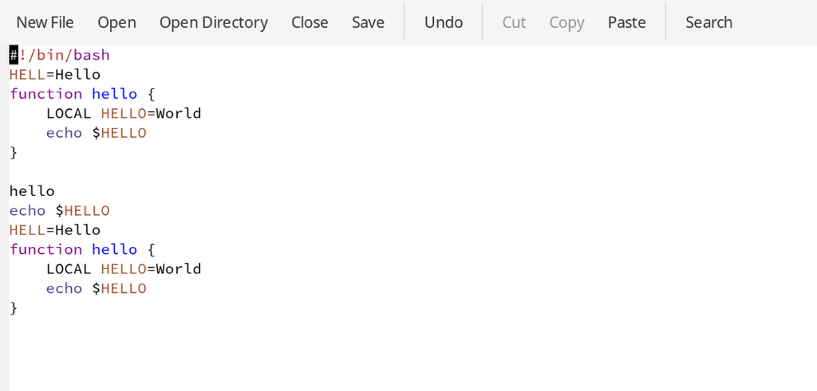

Курсор в начале текста

## Выполнение лабораторной работы

Перемещаю курсор в конец текста (M->)

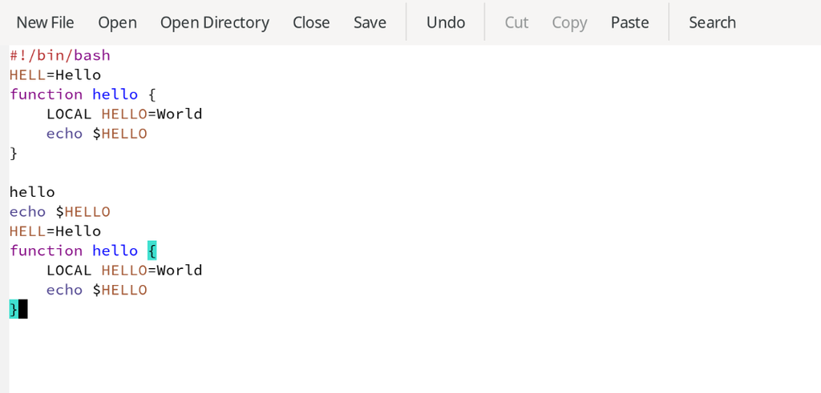

Курсор в конце текста

## Выполнение лабораторной работы

Вывожу список активных буферов на экран (C-x C-b)

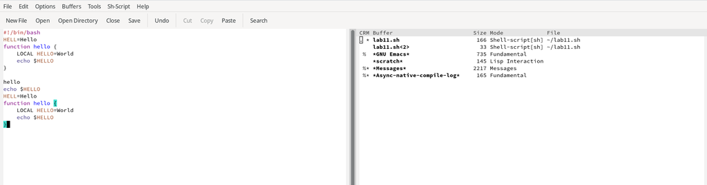

Вывод всех активных буферов

## Выполнение лабораторной работы

Перемещаюсь во вновь открытое окно (C-x) со списком открытых буферов и переключаюсь на другой буфер. Закрываю окно (C-x 0)

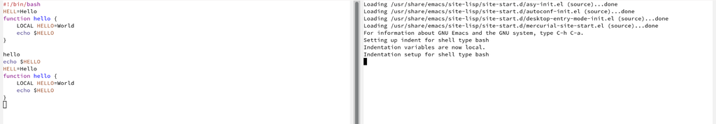

Другой буфер

## Выполнение лабораторной работы

Делю фрейм на 4 части

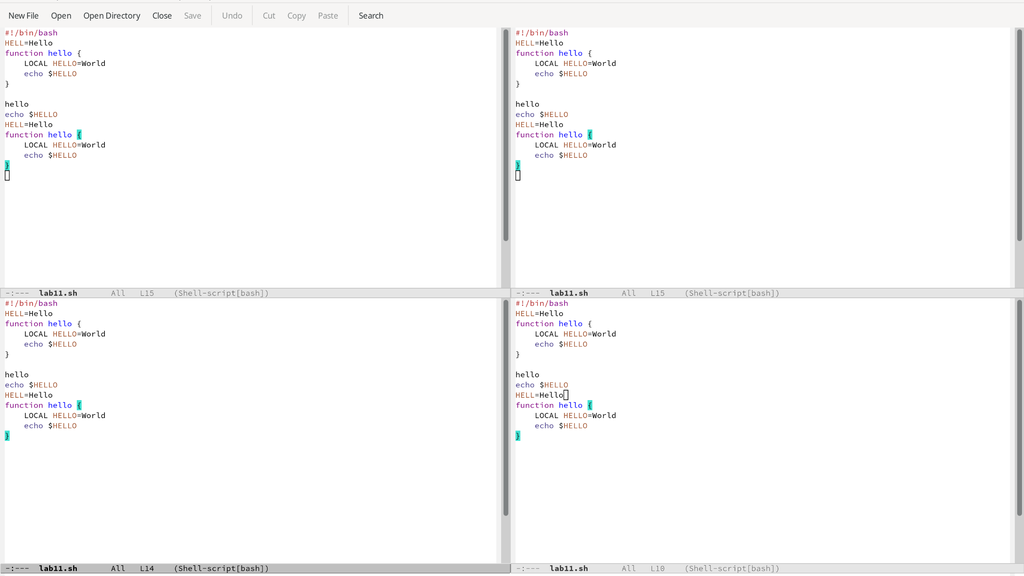

Деление фрейма на 4 части

## Выполнение лабораторной работы

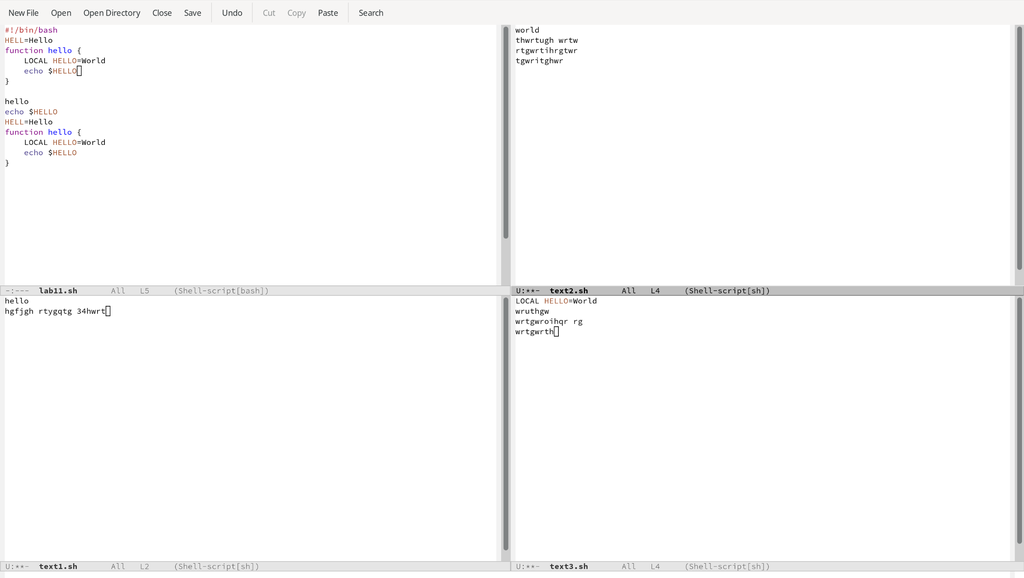

Новые текстовые файлы

## Выполнение лабораторной работы

Переключаюсь в режим поиска (C-s) и нахожу несколько слов, присутствующих в тексте

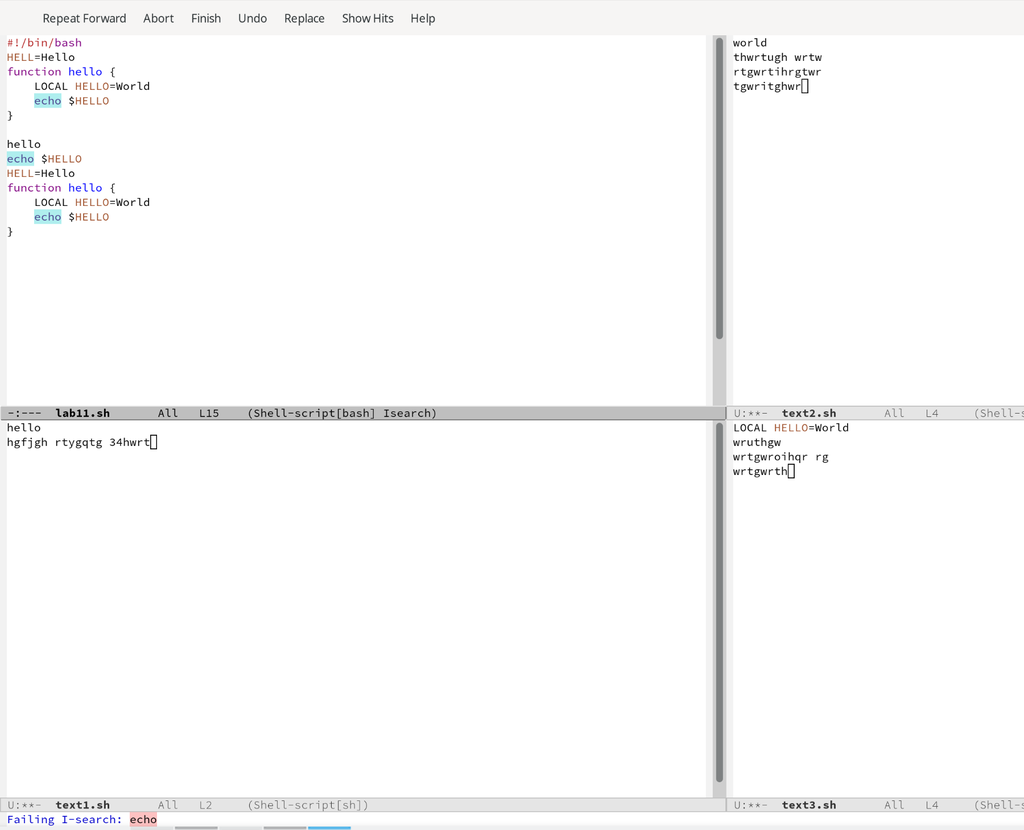

Поиск слов

## Выполнение лабораторной работы

Нажимая C-s, переключаюсь между результатами поиска

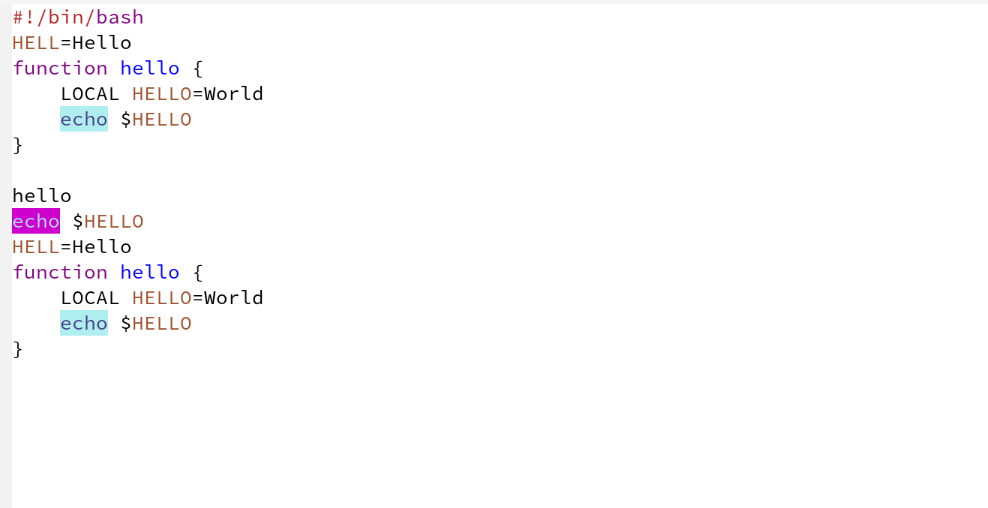

Переключение между результатами поиска

## Выполнение лабораторной работы

Выхожу из режима поиска, нажав C-g

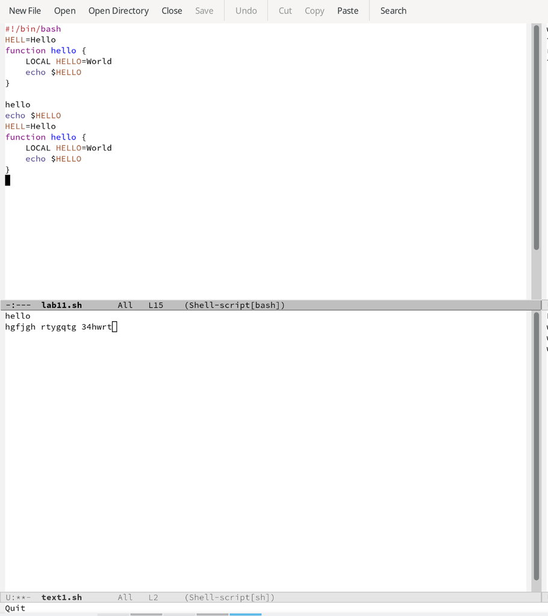

Выход из режима поиска

## Выполнение лабораторной работы

Перехожу в режим поиска и замены (M-%), ввожу текст, который следует найти и заменить, нажимаю Enter, ввожу текст для замены. После того как будут подсвечены результаты поиска, нажимаю ! для подтверждения замены

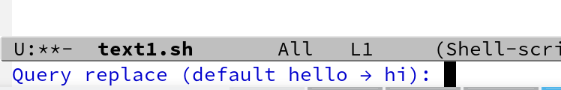

Замена текста

## Выполнение лабораторной работы

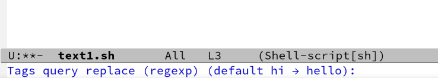

Другой режим поиска

## Выводы

При выполнении данной лабораторной работы я получила практические навыки работы с редактором Emacs.

## Список литературы

1. Лабораторная работа №11 [Электронный ресурс]